# CSV files

Andrew Ba Tran

This is from the [second chapter](https://learn.r-journalism.com/en/importing_exporting/csv/csv-files/) of [learn.r-journalism.com](https://learn.r-journalism.com/).

Comma separated files are the most common way to save spreadsheets that doesn’t require a paid program from Microsoft to open.

## What a csv file looks like

CSV file names end with a **.csv**

[figure not shown]

## What a csv file looks like on the inside

This explains the values separated with commas part of the file name.

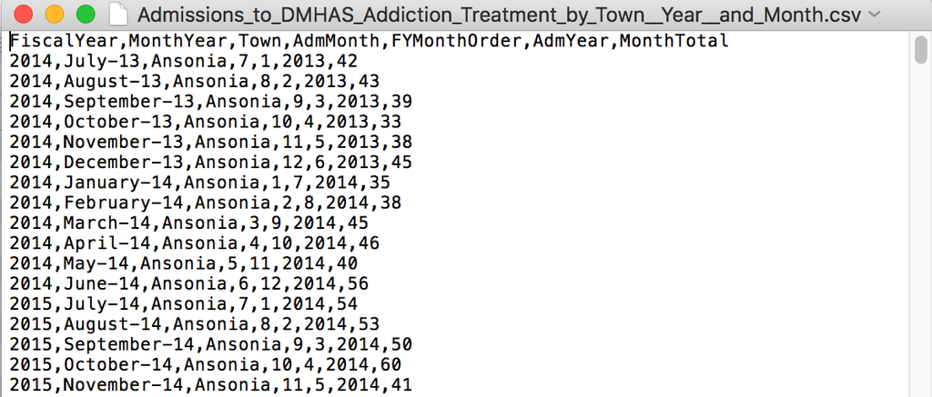

# Importing CSV files

- Importing CSV is part of base R, no package needed
- But we’re going to use a package anyway, **readr**

## Two ways to get data

- If you have the URL address
  - If the csv file exists on the internet, you don’t have to download it to your local machine and then import it, you can import it to R directly from the web using the link
- If you have the file on your computer

## Get the URL

If you have the link to a CSV file, right click [the link](https://data.ct.gov/Health-and-Human-Services/Admissions-to-DMHAS-Addiction-Treatment-by-Town-Ye/iyru-82zq/data) of the data and click **Copy Link Address**. This data set can be found on the [Connecticut Open Data Portal](https://data.ct.gov/Health-and-Human-Services/Admissions-to-DMHAS-Addiction-Treatment-by-Town-Ye/iyru-82zq/).

[figure not shown]

## read.csv()

The Base R function to import a CSV file is `read.csv()`. Just put the URL address in quotation marks and add the `stringsAsFactors=F` (In this code we’re using the function `head()`– this returns 6 rows by default, but we want to look at 10, so we’ll specify that when we call the function head(data, 10))

```r
df_csv <- read.csv("https://data.ct.gov/api/views/iyru-82zq/rows.csv?accessType=DOWNLOAD", stringsAsFactors=F)
head(df_csv, 10)
```

```
##    FiscalYear    MonthYear    Town AdmMonth FYMonthOrder AdmYear
## 1        2014      July-13 Ansonia        7            1    2013
## 2        2014    August-13 Ansonia        8            2    2013
## 3        2014 September-13 Ansonia        9            3    2013
## 4        2014   October-13 Ansonia       10            4    2013
## 5        2014  November-13 Ansonia       11            5    2013
## 6        2014  December-13 Ansonia       12            6    2013
## 7        2014   January-14 Ansonia        1            7    2014
## 8        2014  February-14 Ansonia        2            8    2014
## 9        2014     March-14 Ansonia        3            9    2014
## 10       2014     April-14 Ansonia        4           10    2014
##    MonthTotal
## 1          42
## 2          43
## 3          39
## 4          33
## 5          38
## 6          45
## 7          35
## 8          38
## 9          45
## 10         46
```

## The other way to import the data: Download it

When you right click on the link, instead of clicking **Copy Link Address**– this time, click **Save Link As…**

[figure not shown]

Save to your working directory.

After saving to the directory, click on the circle arrow on the right to refresh the files to make sure it’s there.

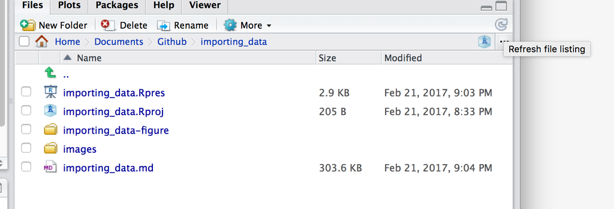

## Recall: How to change directories in RStudio

Either by typing `setwd("/directory/where/you/want")` or by clicking in the menu up top **Session > Set Working Directory > Choose Directory…**

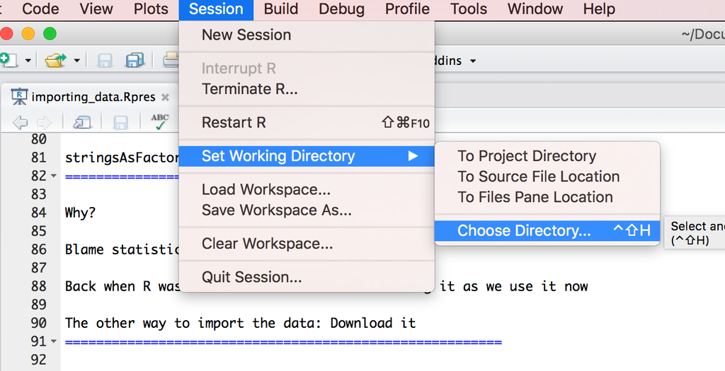

## Importing local csv data

Just like before, except instead of the URL, it’s the name of the file.

**Note:** This will only work if the working directory is set to where the csv file is.

```r
df_csv <- read.csv("data/Admissions_to_DMHAS_Addiction_Treatment_by_Town__Year__and_Month.csv", stringsAsFactors=F)
```

## stringsAsFactors=F

Why?

Blame statisticians.

Back when R was created the users weren’t using it as we use it now, with all these different strings.

**What happens when you don’t use `stringsAsFactors=F`**

```r
df_csv <- read.csv("data/Admissions_to_DMHAS_Addiction_Treatment_by_Town__Year__and_Month.csv")
str(df_csv)
```

```
## 'data.frame':    3420 obs. of  7 variables:
##  $ FiscalYear  : int  2014 2014 2014 2014 2014 2014 2014 2014 2014 2014 ...
##  $ MonthYear   : Factor w/ 36 levels "April-14","April-15",..: 16 4 34 31 28 7 13 10 22 1 ...
##  $ Town        : Factor w/ 102 levels "Ansonia","Berlin",..: 1 1 1 1 1 1 1 1 1 1 ...
##  $ AdmMonth    : int  7 8 9 10 11 12 1 2 3 4 ...
##  $ FYMonthOrder: int  1 2 3 4 5 6 7 8 9 10 ...
##  $ AdmYear     : int  2013 2013 2013 2013 2013 2013 2014 2014 2014 2014 ...
##  $ MonthTotal  : int  42 43 39 33 38 45 35 38 45 46 ...
```

## Using read_csv() from the readr package

**readr** is a package that read rectangular data quickly and assumes characters are strings and not factors by default.

```r
## If you don't have readr installed yet, uncomment and run the line below
#install.packages("readr")
library(readr)
df_csv <- read_csv("data/Admissions_to_DMHAS_Addiction_Treatment_by_Town__Year__and_Month.csv")
```

# Exporting CSV files

When you’re done analyzing or transforming your data, you can save your dataframe as a CSV file with `write_csv()` from the **readr** package.

```r
# Pass the write_csv() function the name of the dataframe and what you want to call the file
write_csv(df_csv, "transformed_data.csv")
```

The file will save to your working directory, but you can specify sub directories with the function.

```r
# Pass the write_csv() function the name of the dataframe and what you want to call the file
write_csv(df_csv, "data/transformed_data.csv")
```

## Exporting data frames with `NA`

Weird quirk alert: Exported files will include `NA`s so to replace them, pass the variable `na="whatever"`.

```r
# This replaces the NAs with blanks
write_csv(df_csv, "data/transformed_data.csv", na="")
```

## Your turn

Challenge yourself with [these exercises](http://code.r-journalism.com/chapter-2/#section-csvs) so you’ll retain the knowledge of this section.

Instructions on how to run the exercise app are on the [intro page](http://learn.r-journalism.com/en/importing_exporting/) to this section.